# First Homework

# 4. Question: Policy Domains

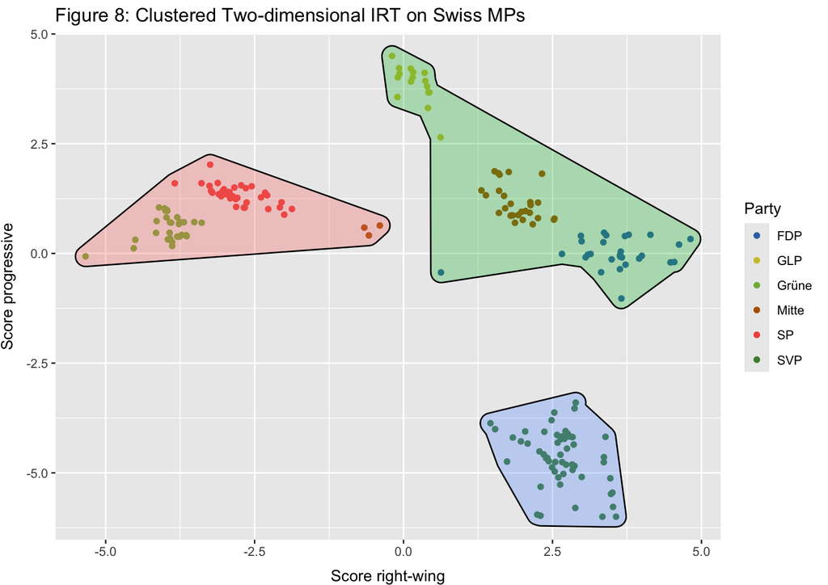

I cluster the MPs using kmeans. ASW yields an optimal number of six clusters or (slightly less optimally) three clusters. Since the 6-clustering is almost identical to the six party “clusters”, I choose the 3-clustering, shown in Figure 8. There is a left cluster of SP, Grüne and the three outlier Mitte MPs, a right cluster of GLP, Mitte and FDP, and a separate cluster of SVP. Figure 9 shows for each policy domain, what share of bills has been sponsored by the left, right and SVP cluster. Only bills that have been voted on in the 51st legislature and only policy domains with at least six bills are included. Across all these bills, the share of sponsored bills is 38% for the left cluster, 37% for the right cluster and 25% for the SVP cluster. The left cluster is most “overrepresented” in the environmental domain (67% of all bills), which isn’t surprising, followed by migration, the economy and agriculture (44% of all bills each), all of which are policy domains which aren’t typically attributed to the left. The right cluster sponsors a disproportionate amount of bills on international affairs (57% of all bills), which is a policy domain that typically wouldn’t necessarily be attributed to any party or cluster, followed by health and the financial sector (52% and 50% of all bills), the latter of which being a hallmark topic for the right. Finally, SVP sponsors more bills on migration (56%), which is again not surprising, followed by energy and public finances (43% and 38%). Additional surprising findings are that SVP isn’t overrepresented in the agricultural domain (25% of all bills) and that the left and right cluster sponsor the same share of bills in the civil rights domain (each 41& of all bills), which would typically be attributed to the left. A survey asking voters what political topics are important to them (and which party they vote for) would help create a link to assessing substantive representation. One would be able to assess whether a party’s MPs actually focus on the topics that are important to their voters.

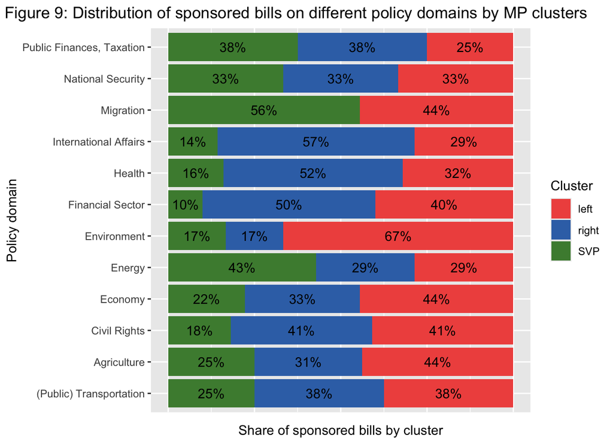

# References

Bornschier, Simon. 2015. “The New Cultural Conflict, Polarization, and Representation in the Swiss Party System, 1975–2011.” *Swiss Political Science Review* 21 (4): 680–701.

Hänggli, Regula, and Silja Häusermann. 2015. “Consensus Lost? Disenchanted Democracy in Switzerland.” *Swiss Political Science Review* 21 (4): 475–90.

Hooghe, Liesbet, Gary Marks, and Carole J Wilson. 2002. “Does Left/Right Structure Party Positions on European Integration?” *Comparative Political Studies* 35 (8): 965–89.

Linder, Wolf, and Sean Mueller. 2017. *Schweizerische Demokratie: Institutionen-Prozesse-Perspektiven*. Haupt Verlag.

———. 2021. “Consensus Democracy: The Swiss System of Power-Sharing.” *Swiss Democracy: Possible Solutions to Conflict in Multicultural Societies*, 167–207.